# Mohn Ridge Frontal Current glider transport analysis (Bosse and Fer, GRL 2019)

This package presents the transport analysis and results of glider data collected across the Mohn Ridge (Nordic Seas).  
It intends to provide a way to repdroduce the results published in [*Bosse, A., & Fer, I. (2019). Mean structure and seasonality of the Norwegian Atlantic Front Current along the Mohn Ridge from repeated glider transects. Geophysical Research Letters, 46(22), 13170-13179.*](https://doi.org/10.1029/2019GL084723), but also enable users to apply the method to other glider data sets aiming at describing geostrophic currents and transport.  
This notebook was written in Matlab and can be run with Octave, an open-source alternative to Matlab.

[contact : anthony.bosse@mio.osupytheas.fr]

```matlab
close all
clear all
warning off
addpath(genpath('.'))
def_fontname % my customized font for plots
```

```
ans =

    '9.8.0.1323502 (R2020a)'
```

## Loading data

First, the final delayed-mode gridded Seaglider data for two missions from the PROVOLO project are loaded from Norwegian Marine Data Center (https://doi.org/10.21335/NMDC-980686647). At this stage, thermal lag issues have been corrected following Garau et al (2011) and an offset calibration on salinity has been compued by comparing with reference CTD casts.  
*This step is skipped in case files already exist.*

```matlab
% check if data are already in data folder
clear sg560 sg562
z = dir('data');
if isempty(find(strcmp({z.name},'final_sg560_MR1.nc'))) | isempty(find(strcmp({z.name},'final_sg562_MR2.nc')))
    ftpobj = ftp('ftp.nmdc.no');
    cd(ftpobj,'nmdc/UIB/PROVOLO/Glider/');
    dir(ftpobj)
    if isempty(find(strcmp({z.name},'final_sg560_MR1.nc'))); mget(ftpobj,'final_sg560_MR1.nc','data'); end
    if isempty(find(strcmp({z.name},'final_sg562_MR2.nc'))); mget(ftpobj,'final_sg562_MR2.nc','data'); end
end
% load data
sg560.glider_name = 'sg560';sg562.glider_name = 'sg562';
sg560.deployment = 'MR1';sg562.deployment = 'MR2';
for file = {'final_sg560_MR1','final_sg562_MR2'}
        l=0;var_short={'JULD','LG','LT','PP','T','SS','DAC_JULD','LGDAC','LTDAC','U','V'};
        for varr = {'JULD','LONGITUDE','LATITUDE','PRES','TEMP','PSAL','DAC_JULD','DAC_LONGITUDE','DAC_LATITUDE','DAC_U','DAC_V'}
        l = l+1;
        eval([file{1}(7:11) '.' var_short{l} ' = ncread(''' file{1} '.nc'',''' varr{1} ''');'])
    end
end
sg560.DAYS = sg560.JULD + datenum(1950,01,01,00,00,00);sg560.DAC_TIME = sg560.DAC_JULD + datenum(1950,01,01,00,00,00);
sg562.DAYS = sg562.JULD + datenum(1950,01,01,00,00,00);sg562.DAC_TIME = sg562.DAC_JULD + datenum(1950,01,01,00,00,00);

% interpolate DAC estimate on profiles
sg560.VX = interp1(sg560.DAC_TIME,sg560.U,sg560.DAYS)';sg562.VX = interp1(sg562.DAC_TIME,sg562.U,sg562.DAYS)';
sg560.VY = interp1(sg560.DAC_TIME,sg560.V,sg560.DAYS)';sg562.VY = interp1(sg562.DAC_TIME,sg562.V,sg562.DAYS)';
sg560.TVEL = sg560.DAYS';sg562.TVEL = sg562.DAYS';sg560.LGV = sg560.LG';sg562.LGV = sg562.LG';sg560.LTV = sg560.LT';sg562.LTV = sg562.LT';
sg560.ZDIVE = nansum(~isnan(sg560.T));sg562.ZDIVE = nansum(~isnan(sg562.T));

% get Conservative Temperature, Absolute Salinity and Potential Density matrix
sg560.SA = gsw_SA_from_SP(sg560.SS,sg560.PP,sg560.LG,sg560.LT);sg562.SA = gsw_SA_from_SP(sg562.SS,sg562.PP,sg562.LG,sg562.LT);
sg560.CT = gsw_CT_from_t(sg560.SA,sg560.T,sg560.PP);sg562.CT = gsw_CT_from_t(sg562.SA,sg562.T,sg562.PP);
sg560.SIG = gsw_sigma0(sg560.SA,sg560.CT);sg562.SIG = gsw_sigma0(sg562.SA,sg562.CT);

% expand time, longitude, latitude matrices in 2D (assuming vertical profiles here)
sg560.DAYS = repmat(sg560.DAYS',size(sg560.PP,1),1);sg562.DAYS = repmat(sg562.DAYS',size(sg562.PP,1),1);
sg560.ZLG = repmat(sg560.LG',size(sg560.PP,1),1);sg562.ZLG = repmat(sg562.LG',size(sg562.PP,1),1);
sg560.ZLT = repmat(sg560.LT',size(sg560.PP,1),1);sg562.ZLT = repmat(sg562.LT',size(sg562.PP,1),1);
sg560.PP = repmat(sg560.PP,1,size(sg560.DAYS,2));sg562.PP = repmat(sg562.PP,1,size(sg562.DAYS,2));
```

We then remove all Depth-Average Current (DAC) estimates for dives shallower than 700m because in our case we focus on estimates of currents offshore and don't want the signal to be polluted by shallow dives the glider may have performed in the middle of the mission.

```matlab
sg560.VX(sg560.ZDIVE<700) = NaN;sg560.VY(sg560.ZDIVE<700) = NaN;
sg562.VX(sg562.ZDIVE<700) = NaN;sg562.VY(sg562.ZDIVE<700) = NaN;
```

We can have a look at the variables in each glider strcuture :

```matlab
sg562
```

```
sg562 =

  struct with fields:

    glider_name: 'sg562'
     deployment: 'MR2'
           JULD: [1396x1 double]
             LG: [1396x1 double]
             LT: [1396x1 double]
             PP: [1011x1396 double]
              T: [1011x1396 double]
             SS: [1011x1396 double]
       DAC_JULD: [698x1 double]
          LGDAC: [698x1 double]
          LTDAC: [698x1 double]
              U: [698x1 double]
              V: [698x1 double]
           DAYS: [1011x1396 double]
       DAC_TIME: [698x1 double]
             VX: [1x1396 double]
             VY: [1x1396 double]
           TVEL: [1x1396 double]
            LGV: [1x1396 double]
            LTV: [1x1396 double]
          ZDIVE: [1x1396 double]
             SA: [1011x1396 double]
             CT: [1011x1396 double]
            SIG: [1011x1396 double]
            ZLG: [1011x1396 double]
            ZLT: [1011x1396 double]
```

We we will be using the gridded data matrix of Conservative Temperature and Absolute Salinity (CT and SA) and DAC estiamtes (VX and VY).

## Computing geostrophic velocities

This is a now crucial step where geostrophic velocities are computed. It follows several steps :

- Calculation of frontal direction given by DAC and angle between the glider track and average current.
- Gridding and smootinh of the T,S sections prior to gradient calculations
- Geostrophic shear is obtained by differentiating the dynamic height and referenced by DAC.
- The angle between DAC and glider track is used to correct the geostrophic velocities, vorticity and distance.

```matlab
% compute Vg and other PV diagnosticis (this step might take a bit of time)
[glid_pv1] = comp_runningPV(sg560,5);[glid_pv2] = comp_runningPV(sg562,5);
```

```
### compute PV for sg560(MR1)
smoothing hor/vert : gaussian 5km / 5m
computing geostr from dyn height: smoothing gaussian 5km
### compute PV for sg562(MR2)
smoothing hor/vert : gaussian 5km / 5m
computing geostr from dyn height: smoothing gaussian 5km
```

```matlab
% Merge glid_pv1 and glid_pv2
varr = fieldnames(glid_pv1);
for ll=3:length(varr)
    eval(['glid_pv.' varr{ll} ' = [glid_pv1.' varr{ll} ' glid_pv2.' varr{ll} '];'])
end
glid_pv.d_along = [glid_pv1.d_along  glid_pv1.d_along(end)+glid_pv2.d_along];
glid_pv.d_cor = nancumsum([0 diff(nanmean(glid_pv.d_along)).*red_x(nanmean(glid_pv.sint))]);

glid_pv
```

```
glid_pv =

  struct with fields:

     dir_flow: [2x2736 double]
           pp: [201x2736 double]
      d_along: [201x2736 double]
          CTs: [201x2736 double]
          SAs: [201x2736 double]
         SIGs: [201x2736 double]
         sint: [201x2736 double]
        v_tot: [201x2736 double]
    v_tot_cor: [201x2736 double]
           ff: [201x2736 double]
           N2: [201x2736 double]
         dBdx: [201x2736 double]
     dBdx_cor: [201x2736 double]
         vort: [201x2736 double]
     vort_cor: [201x2736 double]
         pv_A: [201x2736 double]
         pv_B: [201x2736 double]
           pv: [201x2736 double]
     pv_A_cor: [201x2736 double]
     pv_B_cor: [201x2736 double]
       pv_cor: [201x2736 double]
        d_cor: [1x2736 double]
```

The resulting structure contains the following fields for each glider profile:

- **dir_flow** : the direction of the flow, ie given by the DAC smoothed
- **pp** and **d_along** : pressure and cross-track distance
- **CTs**, **SAs**, **SIGs** : low-pass filtered temperature, salinity and density sections gridded on (pp,d_along)
- **sint** : sinus of angle between DAC and glider track used to get cross-tream velocities (see Appendix of Bosse and Fer (2019) for a schematics)
- **v_tot**, **ff**, **dBdx**, **vort**, **pv_A**, **pv_B**, **pv** (*all fields with "_cor" are geometricaly corrected transformation to .* )
- **d_cor** : the cumulated cross-stream distance along the glider track

## First glimpse at the data

Here, we plot a couple of simple figures to have a first look at the glider data crossing the Mohn-Ridge front.

```matlab
% some colorbar limits
t_lim = [-1 8];s_lim = [35.05 35.4];sp_lim = [0 1];ox_lim = [295 345];
lon_MR = [-3 6];lat_MR = [70.5 73];
wpt_lt = [71+42/60 72+48/60 72+27.69/60 71+22.56/60 71+1.38/60 72+7.32/60 71+47.65/60 70+49.54/60 71+7.44/60 72];
wpt_lg  = [3+18/60 42/60 0.66/60 2+25.05/60 1+22.596/60 -1-4.488/60 -2-7.08/60 0 14.73/60 2];
```

```matlab
% load bathy
load Nordic_ETOPO2.mat
lg_bat = lon;lt_bat = lat;z = elev;
lg_l = [-17 23];lt_l = [61 80];
dx = 25;
indlg_in = find(lg_bat>lg_l(1) & lg_bat<lg_l(2));lg_bat = lg_bat(indlg_in);
indlt_in = find(lt_bat>lt_l(1) & lt_bat<lt_l(2));lt_bat = lt_bat(indlt_in);
z = z(indlt_in,indlg_in);
[lgg_bat ltt_bat] = meshgrid(lg_bat,lt_bat);
```

```matlab
% merge DACs and T,S,SIG
TVEL_all = [sg560.TVEL sg562.TVEL];VX_all = [sg560.VX sg562.VX];VY_all = [sg560.VY sg562.VY];
LGV_all = [sg560.LGV sg562.LGV];LTV_all = [sg560.LTV sg562.LTV];
lg_all = nanmean([sg560.ZLG sg562.ZLG]);lt_all = nanmean([sg560.ZLT sg562.ZLT]);tt_all = nanmean([sg560.DAYS sg562.DAYS]);
SA_all = [sg560.SA sg562.SA];CT_all = [sg560.CT sg562.CT];SIG_all = [sg560.SIG sg562.SIG];PP_all = [sg560.PP sg562.PP];DAYS_all = [sg560.DAYS sg562.DAYS];

% compute MLD with 0.03 kg m^-3 criterion
for l=1:size(CT_all,2)
    MLD_all(l) = compute_mld(PP_all(:,l),SIG_all(:,l),0.03);
end
% get surface, Atlantic Water, deep characteristics
ind_surf = find(nanmean(SA_all(1:20,:))-35.05<0); tmpp = diff(ind_surf); iq_surffront = [ind_surf(1) ind_surf(find(tmpp>3)+1)];
ind_atl = find(nanmean(CT_all(300:400,:))-4>0); tmpp = diff(ind_atl); iq_atlfront = [ind_atl(1) ind_atl(find(tmpp>1)+1)];
ind_deep = find(nanmean(SIG_all(950:end,:))>28.06); tmpp = diff(ind_deep); iq_deepfront = [ind_deep(1) ind_deep(find(tmpp>3)+1)];

% divide the stdudy period in 4 periods
ind1 = 40:465; ind2 = 466:1171; ind3 = 1407:1930;ind4 = 1930:2440;
ind1v = find(TVEL_all>tt_all(ind1(1)) & TVEL_all<tt_all(ind1(end)));
ind2v = find(TVEL_all>tt_all(ind2(1)) & TVEL_all<tt_all(ind2(end)));
ind3v = find(TVEL_all>tt_all(ind3(1)) & TVEL_all<tt_all(ind3(end)));
ind4v = find(TVEL_all>tt_all(ind4(1)) & TVEL_all<tt_all(ind3(end)));
```

We first look at the glider data trajectory on a map with along-track temperature at 300-400m characteristics of the Atlantic Water, and surface 0-20m salinity characteristics of fresh waters from Arctic origin. It nicely show how the Front Current along the Mohn Ridge (separation between warm/cold water at mid-depth) has been crossed many times during the survey.  
*We cut data in four time segments because of the long deployment period (>1year).*

```
printing 300dpi jpg ---> fig/MRall_map
```

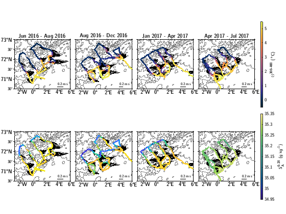

```matlab
close all
lx = .195;ly =.4;
m_proj('equidist','lat',lat_MR,'lon',lon_MR);
for l=1:4
eval(['ind = ind' num2str(l) ';'])
%%%%%%

ax1=axes('position',[.05+(lx+0.02)*(l-1) .5 lx ly]);
if l~=1
    m_grid('linestyle','none','tickdir','out','yticklabel',[])
else
    m_grid('linestyle','none','tickdir','out')
end
hold on;grid on;box on
m_contour(lg_bat,lt_bat,z,[-4000:500:0],'color',[.5 .5 .5])
m_quiver([lon_MR(2)-2 lg_all(ind)],[lat_MR(1)+0.1 lt_all(ind)],[.2 abs(nanmean(glid_pv.v_tot_cor(1:100,ind))).*glid_pv.dir_flow(1,ind)],[0 abs(nanmean(glid_pv.v_tot_cor(1:100,ind))).*glid_pv.dir_flow(2,ind)]*cosd(nanmean(lat_MR)),5,'color',[.2 .2 .2]*0,'ShowArrowHead','off')

m_scatter(lg_all(ind),lt_all(ind),5,nanmean(CT_all(300:400,ind)),'filled')
m_text(lon_MR(2)-2,lat_MR(1)+0.3,'0.2 m s^{-1}','fontsize',5)
colormap(ax1,cmocean('thermal'))

caxis([-0.5 5.5])
if l==4
    h=colorbarnew('v',0.02,1,'\Theta^{300-400} (\circC)');
end
title(['\bf' datestr(tt_all(ind(1)),'mmm YYYY') ' - ' datestr(tt_all(ind(end)),'mmm YYYY')])


ax2=axes('position',[.05+(lx+0.02)*(l-1) .07 lx ly]);
if l~=1
    m_grid('linestyle','none','tickdir','out','yticklabel',[])
else
    m_grid('linestyle','none','tickdir','out')
end
hold on;grid on;box on
m_contour(lg_bat,lt_bat,z,[-4000:500:0],'color',[.5 .5 .5])
m_quiver([lon_MR(2)-2 lg_all(ind)],[lat_MR(1)+0.1 lt_all(ind)],[.2 abs(nanmean(glid_pv.v_tot_cor(1:100,ind))).*glid_pv.dir_flow(1,ind)],[0 abs(nanmean(glid_pv.v_tot_cor(1:100,ind))).*glid_pv.dir_flow(2,ind)]*cosd(nanmean(lat_MR)),5,'color',[.2 .2 .2]*0,'ShowArrowHead','off')
m_scatter(lg_all(ind),lt_all(ind),5,nanmean(SA_all(1:20,ind)),'filled')
m_text(lon_MR(2)-2,lat_MR(1)+0.3,'0.2 m s^{-1}','fontsize',5)

caxis([34.95 35.35])
if l==4
    h=colorbarnew('v',0.02,1,'S_A^{0-20} (g kg^{-1})');
end
end
colormap(ax2,cmocean('haline'))

printHR('fig/MRall_map')
```

Then we can look at the glider Geostrophic velocities, conservative temperature $\Theta$, absolute salinity $S_A$ and potential density $\sigma_0$ from the two glider deployments. The black line show the MLD with its seasonal and spatial evolution.

```
printing 300dpi jpg ---> fig/MRall_section
```

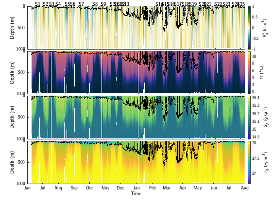

```matlab
% section (Vg,T,S,sigma) with all data
xl = [datenum(2016,6,1) datenum(2017,8,1)];
lx = 0.8;ly = 0.21;
g_lim = [27.5 28.06];
%
ax0=axes('position',[.1 .1+3*(ly+0.01) lx ly],'xticklabel',[]);
hold on;grid on;box on
pcolor(nanmean(DAYS_all),nanmean(glid_pv.pp,2),glid_pv.v_tot_cor);shading flat
plot(tt_all,MLD_all,'-.k','markersize',3)

zdn; ylabel('Depth (m)'); xlim(xl);ylim([0 1000])
h=colorbarnew('v',0.01,1,'V_g^{c} (m s^{-1})'); colormap(ax0,cmocean('delta')); caxis([-1 1])


ax1=axes('position',[.1 .1+2*(ly+0.01) lx ly],'xticklabel',[]);
hold on;grid on;box on
pcolor(tt_all,0:1010,CT_all);shading flat
plot(tt_all,MLD_all,'-.k','markersize',3)

zdn;ylabel('Depth (m)');xlim(xl);ylim([0 1000])
h=colorbarnew('v',0.01,1,'\Theta (\circC)');colormap(ax1,cmocean('thermal'));



ax2=axes('position',[.1 .1+1*(ly+0.01) lx ly],'xticklabel',[]);
hold on;grid on;box on
pcolor(tt_all,0:1010,SA_all);shading flat
plot(tt_all,MLD_all,'-.k','markersize',3)

zdn;ylabel('Depth (m)');xlim(xl);ylim([0 1000])
h=colorbarnew('v',0.01,1,'S_A (g kg^{-1})');colormap(ax2,cmocean('haline'))


ax3=axes('position',[.1 .1 lx ly]);
hold on;grid on;box on
pcolor(tt_all,0:1010,SIG_all);shading flat
plot(tt_all,MLD_all,'-.k','markersize',3)

zdn; ylabel('Depth (m)'); xlabel('Time');xlim(xl);ylim([0 1000])
h=colorbarnew('v',0.01,1,'\sigma_0 (kg m^{-3})');colormap(ax2,cmocean('haline'))

datetick('x','keeplimits')

axes('position',[.1 .1+4*ly+0.025 lx 0.015],'xticklabel',[]);
sec_beg = [40 153 232 299 422 445 553 707 802 930 964 1010 1057 1486 1549 1616 1678 1756 1860 1963 2021 2129 2201 2303 2366];
sec_end = [130 215 277 352 441 538 613 780 872 964 1010 1045 1100 1537 1597 1662 1756 1847 1901 2021 2056 2173 2270 2366 2428];
hold on;
for l=1:length(sec_end)
    plot(nanmean(tt_all([sec_beg(l) sec_end(l)])),0*ones(2,1),'-sb','markersize',2,'markerfacecolor','b')
    text(nanmean(tt_all([sec_beg(l) sec_end(l)]))-2,1,['\bfS' num2str(l)],'fontsize',8)
end
axis off;xlim(xl)

printHR('fig/MRall_section')
```

## Analysis of individual section

A step, not presented here, consist in determinig the indices relevant for each section. We just provide the hard-coded numbers here.

```matlab
sec_beg = [40 153 232 299 422 445 553 707 802 930 964 1010 1057 1486 1549 1616 1678 1756 1860 1963 2021 2129 2201 2303 2366];
sec_end = [130 215 277 352 441 538 613 780 872 964 1010 1045 1100 1537 1597 1662 1756 1847 1901 2021 2056 2173 2270 2366 2428];
rev = [0 1 0 1 0 0 1 0 1 0 1 0 1 0 1 0 1 0 1 0 1 0 1 0 1];
% Build mask from TS space of different water masses, usefull to compute Atlantic Water transport
[sASW_all wASW_all AW_all mAW_all nAW_all NSIW_all NSDW_all] = select_water_mass(SA_all,CT_all);
```

Now the idea is to compute the same anaylsis for individual sections. It follows different steps :

- optimal interpolation of T,S in along-stream distance coordinate system (correlation length of $Lsmo$ and $Zsmo$ chosen at 20km and 15m as in Bosse and Fer (2019), with y=0 defined at the velocity maximum
- vertical shear is obtained from the resulting T,S cross-front distribution and referenced using DAC intensity
- Vg is divided into a geostrophic part (shear integrated above 1000m) and a deep component part (mean absolute geostrophic current between 950-1000m)
- compute different properties such as total transport, AW transport etc  
  (This step can take a bit of time, in particular with the Optimal interpolation step)

```
[row too long to show]
## Front 1/25 : optimal interpolation Vmax = -0.375 m/s, width 65 km , DAC Gaussian fit (-0.2 m/s, 17 km)
### mean transport from optimal interpolation : mean -7.68 Sv -- mean barotropic -4.1472 Sv -- mean baroclinic -3.53 -- Tr AW mean -4.15
printing 300dpi jpg ---> fig/traj_MR1
printing 300dpi jpg ---> fig/radTS_MR1
printing 300dpi jpg ---> fig/radDiag_MR1
printing 300dpi jpg ---> fig/TS_MR1
printing 300dpi jpg ---> fig/Insta_MR1
printing 300dpi jpg ---> fig/watermass_MR1
[row too long to show]
## Front 2/25 : optimal interpolation Vmax = -0.495 m/s, width 55 km , DAC Gaussian fit (-0.15 m/s, 15 km)
### mean transport from optimal interpolation : mean -4.49 Sv -- mean barotropic 0.57921 Sv -- mean baroclinic -5.07 -- Tr AW mean -3.75
printing 300dpi jpg ---> fig/traj_MR2
printing 300dpi jpg ---> fig/radTS_MR2
printing 300dpi jpg ---> fig/radDiag_MR2
printing 300dpi jpg ---> fig/TS_MR2
printing 300dpi jpg ---> fig/Insta_MR2
printing 300dpi jpg ---> fig/watermass_MR2
[row too long to show]
## Front 3/25 : optimal interpolation Vmax = -0.864 m/s, width 28 km , DAC Gaussian fit (-0.19 m/s, 10 km)
### mean transport from optimal interpolation : mean -2.56 Sv -- mean barotropic 2.8108 Sv -- mean baroclinic -5.37 -- Tr AW mean -3.36
printing 300dpi jpg ---> fig/traj_MR3
printing 300dpi jpg ---> fig/radTS_MR3
printing 300dpi jpg ---> fig/radDiag_MR3
printing 300dpi jpg ---> fig/TS_MR3
printing 300dpi jpg ---> fig/Insta_MR3
printing 300dpi jpg ---> fig/watermass_MR3
[row too long to show]
## Front 4/25 : optimal interpolation Vmax = -0.519 m/s, width 40 km , DAC Gaussian fit (-0.14 m/s, 8.1 km)
### mean transport from optimal interpolation : mean -2.85 Sv -- mean barotropic 1.3063 Sv -- mean baroclinic -4.16 -- Tr AW mean -2.88
printing 300dpi jpg ---> fig/traj_MR4
printing 300dpi jpg ---> fig/radTS_MR4
printing 300dpi jpg ---> fig/radDiag_MR4
printing 300dpi jpg ---> fig/TS_MR4
printing 300dpi jpg ---> fig/Insta_MR4
printing 300dpi jpg ---> fig/watermass_MR4
[row too long to show]
## Front 5/25 : optimal interpolation Vmax = -0.567 m/s, width 15 km , DAC Gaussian fit (-0.25 m/s, 4.9 km)
### mean transport from optimal interpolation : mean -3.11 Sv -- mean barotropic -1.1115 Sv -- mean baroclinic -2 -- Tr AW mean -1.98
printing 300dpi jpg ---> fig/traj_MR5
```

[output cut: 185 more lines]

```
printing 300dpi jpg ---> fig/traj_MR24
printing 300dpi jpg ---> fig/radTS_MR24
printing 300dpi jpg ---> fig/radDiag_MR24
printing 300dpi jpg ---> fig/TS_MR24
printing 300dpi jpg ---> fig/Insta_MR24
printing 300dpi jpg ---> fig/watermass_MR24
[row too long to show]
## Front 25/25 : optimal interpolation Vmax = -0.399 m/s, width 72 km , DAC Gaussian fit (-0.18 m/s, 9.6 km)
### mean transport from optimal interpolation : mean -3.88 Sv -- mean barotropic 0.079768 Sv -- mean baroclinic -3.96 -- Tr AW mean -3.32
printing 300dpi jpg ---> fig/traj_MR25
printing 300dpi jpg ---> fig/radTS_MR25
printing 300dpi jpg ---> fig/radDiag_MR25
printing 300dpi jpg ---> fig/TS_MR25
printing 300dpi jpg ---> fig/Insta_MR25
printing 300dpi jpg ---> fig/watermass_MR25
```

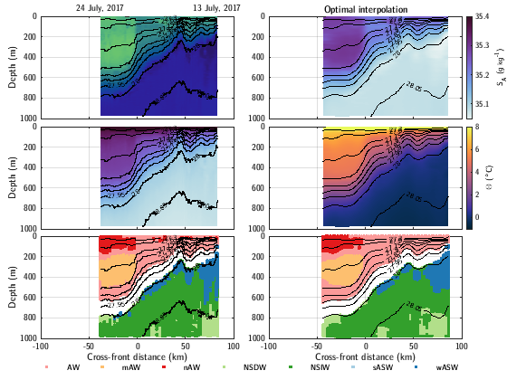

```matlab
% get along-track distance and along-stream distance (perpendicular to DAC)
d_along = nanmean(glid_pv.d_along); dc_along = glid_pv.d_cor;
reload_io = 0; % set to 1 to force reloading optimal interpolation
zz = dir('data');
clear glid_MR TR
if ~isempty(find(strcmp({zz.name},'glid_MR.mat')))
    load('data/glid_MR.mat')
else
    reload_io = 1; % if no matfile then force to reload optimal interpolation
end

for ll= 1:length(sec_beg)
    opt_vis = 0;
    glid_MR.Lsmo = 20;glid_MR.Zsmo = 15;glid_MR.err = 0.05; % correlation length scale for OI
    dr = 2.5;dz = 5; % grid resolution for optimal ineterpolation
    comp_glid_section_MR % do the MR front analysis for an individual section
    plot_glid_section_MR % plot some figures % skip to process faster
end
% save results to avoid recomputing everytime
save('data/glid_MR.mat','glid_MR','TR');
```

```matlab
glid_MR
```

```
glid_MR =

  struct with fields:

            Lsmo: 20
            Zsmo: 15
             err: 0.0500
           bin_d: [200x80 double]
           bin_p: [200x80 double]
          vv_bin: [25x80 double]
           CT_io: [200x80x25 double]
          CT_err: [200x80x25 double]
           SA_io: [200x80x25 double]
          SA_err: [200x80x25 double]
           VG_io: [200x80x25 double]
         VGbt_io: [200x80x25 double]
         VGbc_io: [200x80x25 double]
     front_width: [1x25 double]
    front_intens: [1x25 double]
           vsurf: {1x25 cell}
          indneg: {1x25 cell}
       front_ind: {1x25 cell}
        iq_front: {1x25 cell}
        lg_front: [1x25 double]
        lt_front: [1x25 double]
        tt_front: [1x25 double]
         mask_AW: {1x25 cell}
        mask_mAW: {1x25 cell}
        mask_nAW: {1x25 cell}
       mask_NSDW: {1x25 cell}
       mask_NSIW: {1x25 cell}
       mask_sASW: {1x25 cell}
       mask_wASW: {1x25 cell}
       dir_front: [2x25 double]
            iiq1: [1x25 double]
            iiq2: [1x25 double]
       fit_gauss: [25x3 double]
          SIG_io: [200x80x25 double]
     maskio_sASW: [200x80x25 logical]
     maskio_wASW: [200x80x25 logical]
       maskio_AW: [200x80x25 logical]
      maskio_mAW: [200x80x25 logical]
      maskio_nAW: [200x80x25 logical]
     maskio_NSIW: [200x80x25 logical]
     maskio_NSDW: [200x80x25 logical]
      maskio_ASW: [200x80x25 double]
```

At this stage, we have done the front analysis (reconstruction of cross-track TS sections, geostrophic velocities, potential vorticity, detection of water masses, etc for the 25 Mohn Ridge transects stored. Results are stored in **glid_MR** structure.

The analysis also summarized in a series of figures describing each individual section :

- **traj_MR** : map of glider trajectory with DAC, evolution of cross-track and cross-stream distance (solid and dashed lines) with sinus of the angle betweent DAC and glider track.
- **radTS_MR** : sectons of temperature and salinity : profile by profile (left), optimal interpolation used to compute gestrophic velocities (right).
- **radDiag_MR** : sections of frontal geostrophic velocities (left directly from glid_pv struct, right from optimal interpolation of T,S sections, the right option was chosen in Bosse and Fer GRL 2019). The transport (total down to 1000m and AW only) along the front is also integrated in the magenta square (boundaries defined as in the paper).
- **TS_MR** shows a TS diagram of the section with dots colored with distance from the font center (left) and geostrophic velocities (right)
- **Insta_MR** shows the Potential Vorticity (bottom right) and decomposition in the sum of two terms (right column). The instability regimes deduced from the PV anaylsir following [Thomas et al (DSR 2013)](http://dx.doi.org/10.1016/j.dsr2.2013.02.025) are shown in the upper left panel. NB : This analysis is done with the profile by profile glid_pv strcuture, this could be done with the optimally interpolated fields.
- **watermass_MR** shows the frontal section and corresponding water masses (left profile by profile, right optimal interpolation)

```matlab
glid_MR
```

```
glid_MR =

  struct with fields:

            Lsmo: 20
            Zsmo: 15
             err: 0.0500
           bin_d: [200x80 double]
           bin_p: [200x80 double]
          vv_bin: [25x80 double]
           CT_io: [200x80x25 double]
          CT_err: [200x80x25 double]
           SA_io: [200x80x25 double]
          SA_err: [200x80x25 double]
           VG_io: [200x80x25 double]
         VGbt_io: [200x80x25 double]
         VGbc_io: [200x80x25 double]
     front_width: [1x25 double]
    front_intens: [1x25 double]
           vsurf: {1x25 cell}
          indneg: {1x25 cell}
       front_ind: {1x25 cell}
        iq_front: {1x25 cell}
        lg_front: [1x25 double]
        lt_front: [1x25 double]
        tt_front: [1x25 double]
         mask_AW: {1x25 cell}
        mask_mAW: {1x25 cell}
        mask_nAW: {1x25 cell}
       mask_NSDW: {1x25 cell}
       mask_NSIW: {1x25 cell}
       mask_sASW: {1x25 cell}
       mask_wASW: {1x25 cell}
       dir_front: [2x25 double]
            iiq1: [1x25 double]
            iiq2: [1x25 double]
       fit_gauss: [25x3 double]
          SIG_io: [200x80x25 double]
     maskio_sASW: [200x80x25 logical]
     maskio_wASW: [200x80x25 logical]
       maskio_AW: [200x80x25 logical]
      maskio_mAW: [200x80x25 logical]
      maskio_nAW: [200x80x25 logical]
     maskio_NSIW: [200x80x25 logical]
     maskio_NSDW: [200x80x25 logical]
      maskio_ASW: [200x80x25 double]
```

In this strcuture, we have the following variables :

- **Lsmo**, **Zsmo**, **err** the correlation scales in x and z direction and error for optimal interpolation
- **bin_d**, **bin_p** the cross-stream distance and pressure grid used for optimal interpolation
- **vv_bin** DAC binned along distance into for the 25 sections
- **CT_io**,**CT_err** are optiamlly interpolated temperature section with associated error (same for absolute salinity **SA** and potential density **SIG**)
- **VG_io** cross-streal geostrophic velocities from optimal interpolation of TS sections
- **front_width** and **front_intens** : width and intensity of front from profil by profil geostrophic velocities (first approach)
- **vsurf** 0-50m average geostrophic profile by profile velocity; **indneg** indexes of negative velocities
- **iiq1** and **iiq2** set the limit on OI grid of the front for transport integration
- **dir_front** 2D vectors showing the frontal jet direction at peak velocity for the 25 sections
- **fit_gauss** the 3 parameters the gaussian fit of depth-average currents along the front ($x_0$,$V_0$,$\sigma$)
- **mask_** profile by profile masks for different water masses and each section (**mask_*_io** same for optimally interpolated TS sections)

## Compute mean section and climatology

Now we can merge the transport estimates and build the mean annual and seasonal sections.

```matlab
% synthesis transport
for transp = {'','bt','bc'} % mass heat salt
    for varr = {'','H','S'} % mass heat salt
    % different water masses
        for watermass = {'','AW','mAW','nAW','NSDW','NSIW','sASW','wASW'}
        eval([transp{1} varr{1} 'Tr' watermass{1} ' = -[TR.' transp{1} varr{1} 'Tr' watermass{1} '];'])
        end
    end
end
month_front = str2num(datestr(tt_front,'mm'));
front_width = (glid_MR.iiq2-glid_MR.iiq1)*dr;
front_width_gauss = glid_MR.fit_gauss(:,3);
```

```
printing 300dpi jpg ---> fig/MRmeanSection_zmean
printing 300dpi jpg ---> fig/MRmeanSection_zmean_seas1
printing 300dpi jpg ---> fig/MRmeanSection_zmean_seas2
printing 300dpi jpg ---> fig/MRmeanSection_zmean_seas3
```

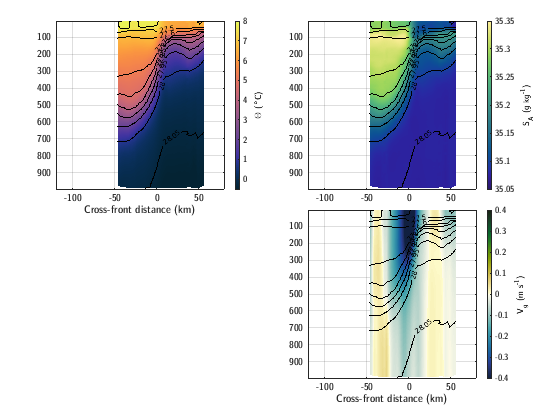

```matlab
iqJFMA_all = find(month_front==1 | month_front==2 | month_front==3 | month_front==4);
iqMJJA_all = find(month_front==5 | month_front==6 | month_front==7 | month_front==8);
iqSOND_all = find(month_front==9 | month_front==10 | month_front==11 | month_front==12);

load data/zz_smo.mat
lgg = linspace(lon_MR(2),lon_MR(1),500);ltt = linspace(lat_MR(1),lat_MR(2),500);
[xx yy] = earthcoord('flat',lgg,ltt,nanmean(lg_front),nanmean(lt_front));
[xx_p yy_p] = project_pt(xx,yy,-nanmean(dir_front(1,:))/nanmean(dir_front(2,:)),0);
[lggg lttt] = xy_to_lglt(xx_p,yy_p,nanmean(lg_front),nanmean(lt_front));
batfront = interp2(lg_bat,lt_bat,z_smo,lg_front,lt_front);

col_paired = paired();

[x_front y_front] = earthcoord('flat',lg_front,lt_front,nanmean(lg_front),nanmean(lt_front));
[xfront_p yfront_p] = project_pt(x_front,y_front,-nanmean(dir_front(1,:))/nanmean(dir_front(2,:)),0);
[lgfront_p ltfront_p] = xy_to_lglt(xfront_p,yfront_p,nanmean(lg_front),nanmean(lt_front));

batsmo_mean = interp2(lg_bat,lt_bat,z_smo,lggg,lttt);bat_mean = interp2(lg_bat,lt_bat,z,lggg,lttt);
[xxx yyy] = earthcoord('flat',lggg,lttt,nanmean(lgfront_p),nanmean(ltfront_p));
ddd = [0 cumsum(sqrt(diff(xxx).^2+diff(yyy).^2))];
ddd = ddd - interp1(lttt,ddd,nanmean(ltfront_p));

% compute average section
compute_avMR

% make_MRclimato
% plot mean section
xx=dd_grid;yy=pp_grid;tt=CT_mean;ss=SA_mean;vg=VG_mean;sig=SIG_mean;vger=VG_err;opt='_zmean';nnobs=nobs;plot_meanMR
for k=1:3
tt=ct_seas(:,:,k);ss=sa_seas(:,:,k);vg=vg_seas(:,:,k);sig=sig_seas(:,:,k);vger=vg_err_seas(:,:,k);opt=['_zmean_seas' num2str(k)];nnobs=nobs_seas(:,:,k);plot_meanMR
end
```

## Synthesis of transport estimates

We can now reproduce figures (slightly different as the one in Bosse and Fer (2019) as no cruise data are here integrated and the method has been reduced to the core of the front analysis.

```
printing 300dpi jpg ---> fig/map_MR_intro
```

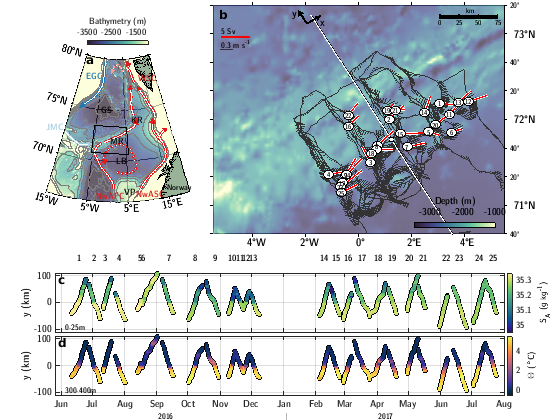

```matlab
% figure 1 similar of Bosse and Fer, GRL 2019
plot_paper_MRmap
```

```
printing 300dpi jpg ---> fig/paper_TSV
printing 300dpi jpg ---> fig/paper_TSV_seas
printing 300dpi jpg ---> fig/paper_water_seas
```

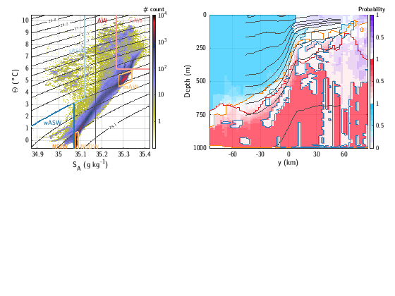

```matlab
% figure 2 similar of Bosse and Fer, GRL 2019 and other figures (seasonal front strcuture and water mass detection)
plot_paper_MRmeansection
```

```matlab
% display some front characteristics and build latex table
get_PF_charac
```

```
#1 max vel : -0.389m/s @ 3.75km, 2.5m, geostr shear comp -0.28m/s, 1000m comp -0.11m/s
#2 max vel : -0.52m/s @ -1.25km, 37.5m, geostr shear comp -0.52m/s, 1000m comp -0.0015m/s
#3 max vel : -0.941m/s @ -1.25km, 2.5m, geostr shear comp -1.1m/s, 1000m comp 0.14m/s
#4 max vel : -0.57m/s @ -1.25km, 2.5m, geostr shear comp -0.63m/s, 1000m comp 0.057m/s
#5 max vel : -0.596m/s @ 1.25km, 62.5m, geostr shear comp -0.52m/s, 1000m comp -0.073m/s
#6 max vel : -0.734m/s @ -1.25km, 77.5m, geostr shear comp -0.72m/s, 1000m comp -0.012m/s
#7 max vel : -0.781m/s @ 1.25km, 2.5m, geostr shear comp -0.75m/s, 1000m comp -0.036m/s
#8 max vel : -0.718m/s @ 1.25km, 97.5m, geostr shear comp -0.66m/s, 1000m comp -0.063m/s
#9 max vel : -0.511m/s @ 1.25km, 2.5m, geostr shear comp -0.45m/s, 1000m comp -0.057m/s
#10 max vel : -0.66m/s @ 3.75km, 112.5m, geostr shear comp -0.64m/s, 1000m comp -0.019m/s
#11 max vel : -0.517m/s @ 3.75km, 2.5m, geostr shear comp -0.47m/s, 1000m comp -0.045m/s
#12 max vel : -0.486m/s @ 3.75km, 2.5m, geostr shear comp -0.45m/s, 1000m comp -0.035m/s
#13 max vel : -0.568m/s @ -1.25km, 2.5m, geostr shear comp -0.53m/s, 1000m comp -0.041m/s
#14 max vel : -0.582m/s @ 3.75km, 2.5m, geostr shear comp -0.54m/s, 1000m comp -0.039m/s
#15 max vel : -0.777m/s @ -3.75km, 2.5m, geostr shear comp -0.81m/s, 1000m comp 0.035m/s
#16 max vel : -0.468m/s @ 1.25km, 2.5m, geostr shear comp -0.43m/s, 1000m comp -0.038m/s
#17 max vel : -0.51m/s @ -1.25km, 2.5m, geostr shear comp -0.56m/s, 1000m comp 0.051m/s
#18 max vel : -0.61m/s @ 3.75km, 2.5m, geostr shear comp -0.74m/s, 1000m comp 0.13m/s
#19 max vel : -0.391m/s @ -1.25km, 2.5m, geostr shear comp -0.35m/s, 1000m comp -0.038m/s
#20 max vel : -0.372m/s @ -1.25km, 2.5m, geostr shear comp -0.35m/s, 1000m comp -0.026m/s
#21 max vel : -0.488m/s @ 3.75km, 2.5m, geostr shear comp -0.37m/s, 1000m comp -0.11m/s
#22 max vel : -0.357m/s @ 3.75km, 2.5m, geostr shear comp -0.32m/s, 1000m comp -0.034m/s
#23 max vel : -0.637m/s @ 3.75km, 2.5m, geostr shear comp -0.66m/s, 1000m comp 0.024m/s
#24 max vel : -0.81m/s @ 1.25km, 52.5m, geostr shear comp -0.84m/s, 1000m comp 0.029m/s
#25 max vel : -0.424m/s @ -1.25km, 67.5m, geostr shear comp -0.41m/s, 1000m comp -0.014m/s
JFMA : Vmax = -0.57+/-0.11m/s, geostrophic shear -0.55+/-0.14m/s, 1000m comp -0.011+/-0.042m/s
MJJA : Vmax = -0.55+/-0.19m/s, geostrophic shear -0.56+/-0.26m/s, 1000m comp 0.0049+/-0.082m/s
SOND : Vmax = -0.65+/-0.11m/s, geostrophic shear -0.6+/-0.12m/s, 1000m comp -0.044+/-0.022m/s
width_int = 35+/-11km
fit_gauss sigma = 12+/-4.2km
JFMA : width_int = 36+/-6.1km
JFMA : fit_gauss sigma = 13+/-4km
MJJA : width_int = 36+/-13km
MJJA : fit_gauss sigma = 12+/-4.5km
SOND : width_int = 30+/-13km
SOND : fit_gauss sigma = 9.9+/-4.5km
\begin{table}
\small
\begin{tabular}{lc|ccc|c}
 & units & Winter (JFMA) & Summer (MJJA) & Fall (SOND) & Annual \\ \hline
$n$ &  & 6 & 11 & 7 & 24 \\
$U_{max}$ & m\,s$^{-1}$ & 0.57$\pm$0.05 & 0.55$\pm$0.06 & 0.65$\pm$0.04 & 0.55$\pm$0.03 \\
$U^{shear}_{max}$ $\vert$ $U^{1000}_{max}$ & m\,s$^{-1}$ & 0.55$\pm$0.06 $\vert$ 0.01$\pm$0.02 & 0.56$\pm$0.08 $\vert$ -0.00$\pm$0.02 & 0.60$\pm$0.04 $\vert$ 0.04$\pm$0.01 & 0.53$\pm$0.04 $\vert$ 0.02$\pm$0.01\\
$\sigma_{fit}$ & km & 13$\pm$2 & 12$\pm$1 & 10$\pm$2 & 11$\pm$1 \\
$L_{int}$ & km & 36$\pm$2 & 36$\pm$4 & 30$\pm$5 & 35$\pm$2 \\
$Tr_{AW}$ & Sv & 3.4$\pm$0.4 & 3.2$\pm$0.3 & 3.2$\pm$0.3 & 3.3$\pm$0.2 \\
$Tr^{shear}_{AW}$ $\vert$ $Tr^{1000}_{AW}$ & Sv & 3.4$\pm$0.3 $\vert$ -0.0$\pm$0.2 & 2.9$\pm$0.3 $\vert$ 0.3$\pm$0.2 & 2.5$\pm$0.2 $\vert$ 0.7$\pm$0.2 & 3.0$\pm$0.2 $\vert$ 0.3$\pm$0.1 \\
$HTr_{AW}$ & TW & 71$\pm$9 & 67$\pm$8 & 75$\pm$8 & 72$\pm$5 \\
\end{tabular}
\caption{Seasonal and mean Polar Front characteristics (average $\pm$ standard error) : number of independent sections ($n$), maximum absolute frontal velocity ($U_{max}$) decomposed into maximum velocity due to the geostrophic shear above 1000\,m ($U^{shear}_{max}$) and maximum velocity at 1000\,m …
\label{tab-front}
\end{table}
```

```
..............
13112310222222
13112310222222
printing 300dpi jpg ---> tseriesMR_n
```

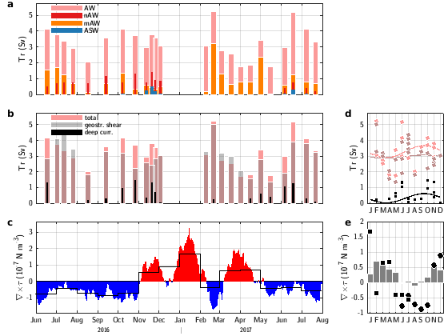

```matlab
% figure 3
plot_paper_MRtseries
```